# hw1_prac.Rmd

Nizov Alexander

2023-02-26

Получим данные (язык Python, прикреплено отдельным файлом).

Далее - язык R.

Данные о ценах закрытия акций Boeing Industrials (тикер BA) с 3.01.2022 до 24.02.2023:

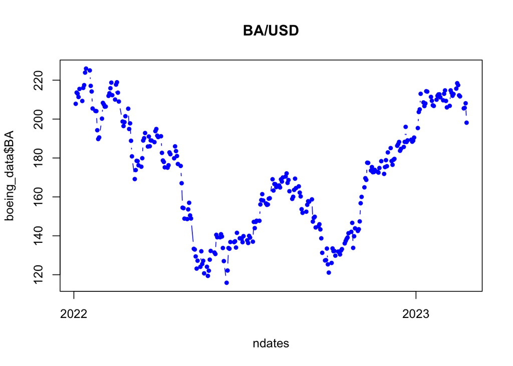

```r
library("readr")
boeing_data <- read_csv("BAdata.csv")
prices <- boeing_data$BA
ndates <- as.Date(boeing_data$Date, "%m/%d/%y")
matplot(ndates, boeing_data$BA, type = "b", pch = 20, col = 'blue', main = "BA/USD")
```

Переходим к доходностям акций BA:

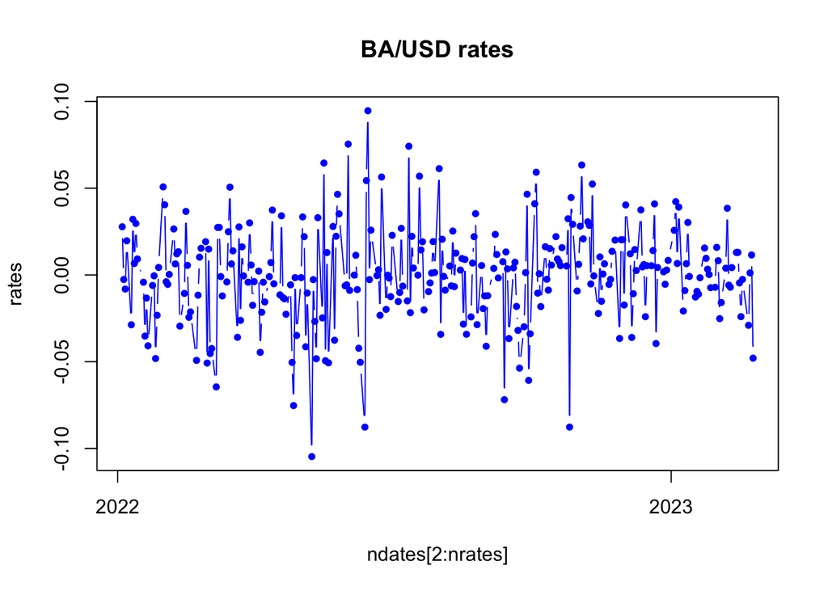

```r
nrates <- length(prices)
rates <- boeing_data$BA[2:nrates]/boeing_data$BA[1:(nrates-1)]-1
matplot(ndates[2:nrates], rates, type = "b", pch = 20, col = 'blue', main = "BA/USD rates")
```

## Гипотеза случайности

```r
library(randtests)
```

Mann-Kendall Rank Test:

```r
rank.test(rates)
```

```
##
##  Mann-Kendall Rank Test
##
## data:  rates
## statistic = 1.3016, n = 287, p-value = 0.193
## alternative hypothesis: trend
```

Bartels Ratio Test:

```r
bartels.rank.test(rates)
```

```
##
##  Bartels Ratio Test
##
## data:  rates
## statistic = -0.33854, n = 287, p-value = 0.735
## alternative hypothesis: nonrandomness
```

Cox Stuart test:

```r
cox.stuart.test(rates)
```

```
##
##  Cox Stuart test
##
## data:  rates
## statistic = 75, n = 143, p-value = 0.616
## alternative hypothesis: non randomness
```

Runs test:

```r
runs.test(rates)
```

```
##
##  Runs Test
##
## data:  rates
## statistic = -0.94776, runs = 136, n1 = 143, n2 = 143, n = 286, p-value
## = 0.3432
## alternative hypothesis: nonrandomness
```

Turning Point test:

```r
turning.point.test(rates)
```

```
##
##  Turning Point Test
##
## data:  rates
## statistic = -0.28088, n = 287, p-value = 0.7788
## alternative hypothesis: non randomness
```

Вывод: Для каждого из пяти тестов p-value больше уровня значимости 0.05, следовательно, гипотеза случайности не отвергается.

## Гипотеза однородности

Рассмотрим две выборки: доходности акций BA первые 124 дня года и вторые 124 дня года:

```r
rates1 <- rates[1:124]
rates2 <- rates[125:248]
```

Критерий Уилкоксона:

```r
wilcox.test(rates1, rates2, paired = T)
```

```
##
##  Wilcoxon signed rank test with continuity correction
##
## data:  rates1 and rates2
## V = 3428, p-value = 0.2655
## alternative hypothesis: true location shift is not equal to 0
```

Критерий Смирнова:

```r
ks.test(rates1, rates2)
```

```
##
##  Asymptotic two-sample Kolmogorov-Smirnov test
##
## data:  rates1 and rates2
## D = 0.19355, p-value = 0.01922
## alternative hypothesis: two-sided
```

Вывод: согласно критерию Уилкоксона со значением p-value больше 0.05, гипотеза не отвергается, однако согласно критерию Смирнова, наоборот, отвергается. Будем мыслить критически и отвергнем гипотезу на основе результатов двух продемонстрированных выше критериев.

## Предложим наиболее адекватный тип распределения для доходностей

```r
library(rriskDistributions)
fit.cont(data2fit = rates)
```

```
##
## Begin fitting distributions ---------------------------------------
```

```
## * fitting normal distribution ... OK
```

```
## * fitting Cauchy  distribution ... OK
```

```
## * fitting logistic distribution ... OK
```

```
## * fitting beta distribution ... failed
```

```
## * fitting exponential distribution ... failed
```

```
## * fitting chi-square distribution ... failed
```

```
## * fitting uniform distribution ... OK
```

```
## * fitting gamma distribution ... failed
```

```
## * fitting lognormal distribution ... failed
```

```
## * fitting Weibull distribution ... failed
```

```
## * fitting F-distribution ... failed
```

```
## * fitting Student's t-distribution ... OK
```

```
## * fitting Gompertz distribution ... failed
```

```
## * fitting triangular distribution ... failed
```

```
## End fitting distributions -----------------------------------------
```

```
##            logL      AIC      BIC Chisq(value) Chisq(p) AD(value)        H(AD)
## Normal    616.2  -1228.4 -1221.09        29.28     0.01      1.56     rejected
## Cauchy   594.22 -1184.43 -1177.11        36.53     0.00      1.98     rejected
## Logistic 622.35 -1240.71 -1233.39        20.64     0.11      0.58 not rejected
## Uniform    NULL     NULL     NULL       183.92     0.00       Inf         NULL
## Student  -264.1    530.2   533.86      8104.27     0.00    103.94         NULL
##          KS(value)        H(KS)
## Normal        0.07 not rejected
## Cauchy        0.06 not rejected
## Logistic      0.04 not rejected
## Uniform       0.11     rejected
## Student       0.47     rejected
```

```
##
## Chosen continuous distribution is: NA
## Fitted parameters are:
## [1] NA
```

## Разделить случайно выборку на две части тренировочную и тестовую

```r
d = sort(sample(length(rates), length(rates)*.5))
train <- rates[d]
test <- rates[-d]
length(test)
```

```
## [1] 144
```

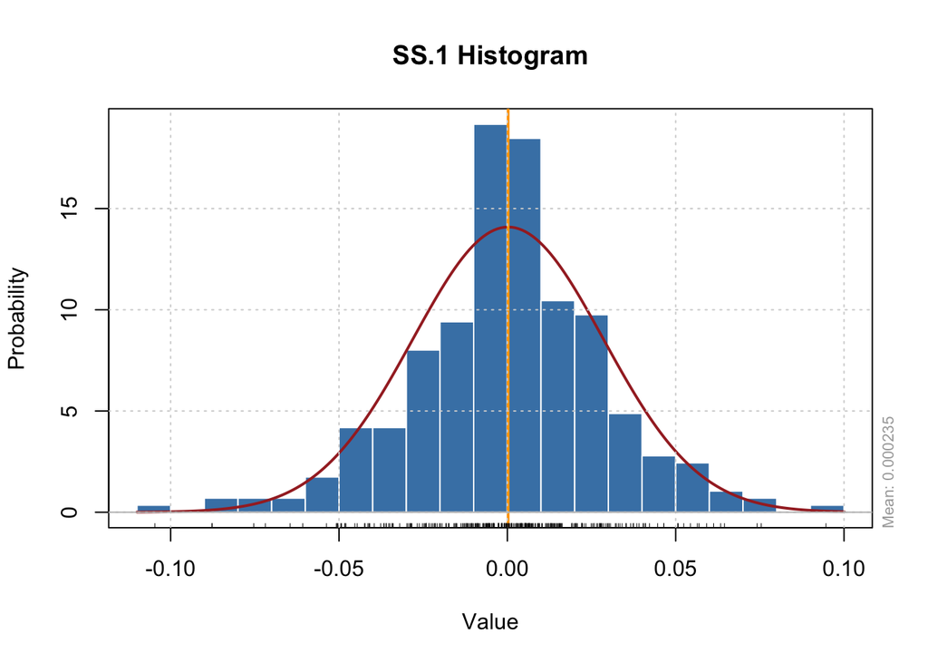

```r
library(fBasics)
library(MASS)
histPlot(as.timeSeries(rates))
```

## Оценка параметров распределения

Оценим методом максимального правдоподобия параметры предполагаемого распределения по тренировочной части выборки:

```r
library(fitdistrplus)
fitting_normal <- fitdistr(train, "normal")
fitting_normal
```

```
##       mean           sd
##   0.001595883   0.028627148
##  (0.002393922) (0.001692759)
```

## Проверить гипотезу согласия с предложенным распределением всей выборки

Воспользуемся критериями Колмогорова-Смирнова и Хи-квадрат Пирсона:

Критерий Колмогорова-Смирнова:

```r
ks.test(rates, 'pnorm', fitting_normal$estimate[1], fitting_normal$estimate[2])
```

```
##
##  Asymptotic one-sample Kolmogorov-Smirnov test
##
## data:  rates
## D = 0.070826, p-value = 0.1123
## alternative hypothesis: two-sided
```

Промежуточный вывод: p-value критерия Колмогорова-Смирнова больше 0.05

Критерий Хи-квадрат Пирсона:

```r
normal_d <- rnorm(length(rates), fitting_normal$estimate[1], fitting_normal$estimate[2])
chisq.test(rates, normal_d)
```

```
##
##  Pearson's Chi-squared test
##
## data:  rates and normal_d
## X-squared = 82082, df = 81796, p-value = 0.2395
```

Вывод: в силу того, что оба критерия показали p-value большу 0.05, гипотеза не отвергается.